# 《鹅鸭杀》Steam 活跃玩家统计与流失大盘预测研究报告

- 显示所有代码
- 隐藏所有代码

基于 Holt-Winters 模型与时序降维的生命周期量化洞察

作者

徐文静

发布日期

2026年2月10日

摘要

本报告以《鹅鸭杀》（Goose Goose Duck）Steam 平台历史月度 CCU 数据为基础，采用月度宏观降维策略规避日级噪音，构建含12个月季节周期的Holt-Winters三次指数平滑模型，预测2026年初至2027年初玩家走势，识别寒暑假流量红利窗口，并提出淡旺季差异化运营落地方案，为游戏精细化版本迭代与营销预算投放提供量化支撑。

# 1 研究背景与核心视角

《鹅鸭杀》（Goose Goose Duck）作为一款现象级的强社交属性派对游戏，其生命周期的演进极具商业与学术研究价值。

本研究的核心目标是：通过历史数据深度洞察该游戏的**月度平均在线基本盘**与**月度最高爆发潜力**，并基于**三次指数平滑模型**前瞻性预测2026年初-2027年初大盘流失与反弹趋势，为游戏接下来的精细化版本迭代和营销预算投放提供量化支撑。

# 2 数据爬取与可视化展示

**代码**

```python
import requests
import pandas as pd
from io import StringIO
import matplotlib.pyplot as plt
plt.rcParams['font.sans-serif'] = ['SimHei']
plt.rcParams['axes.unicode_minus'] = False

url = "https://steamcharts.com/app/1568590"
headers = {
    "User-Agent": "Mozilla/5.0 (Windows NT 10.0; Win64; x64) AppleWebKit/537.36 (KHTML, like Gecko) Chrome/120.0.0.0 Safari/537.36"
}

response = requests.get(url, headers=headers)
if response.status_code != 200:
    print(f"网页抓取失败，状态码: {response.status_code}。请检查网络或代理设置。")
else:
    tables = pd.read_html(StringIO(response.text))
    raw_df = tables[0]

    df = raw_df[raw_df['Month'] != 'Last 30 Days'].copy()

    df['Avg. Players'] = pd.to_numeric(df['Avg. Players'].astype(str).str.replace(',', ''), errors='coerce')
    df['Peak Players'] = pd.to_numeric(df['Peak Players'].astype(str).str.replace(',', ''), errors='coerce')

    df['Date'] = pd.to_datetime(df['Month'], format='%B %Y', errors='coerce')
    df.dropna(subset=['Date'], inplace=True)
    df.set_index('Date', inplace=True)

    df.sort_index(inplace=True)
    plot_df = df.loc['2023-07-01':'2026-01-31']
```

**代码**

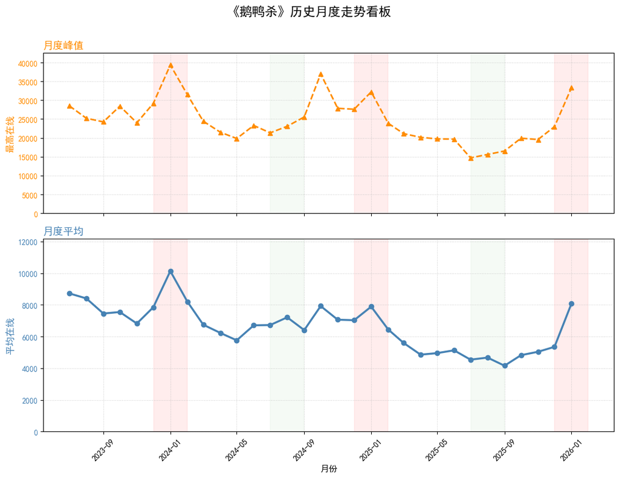

```python
fig, (ax1, ax2) = plt.subplots(nrows=2, ncols=1, figsize=(11, 9), sharex=True, gridspec_kw={'height_ratios': [1, 1.2]})
fig.suptitle('《鹅鸭杀》历史月度走势看板', fontsize=16, fontweight='bold', y=0.96)

# Peak Players
ax1.plot(plot_df.index, plot_df['Peak Players'],
         label='月度在线峰值 (Monthly Peak)', color='darkorange', marker='^', linestyle='--', linewidth=2)
ax1.set_ylabel('最高在线', fontsize=12, fontweight='bold', color='darkorange')
ax1.set_title('月度峰值', fontsize=13, loc='left', color='darkorange')
ax1.grid(True, linestyle=':', alpha=0.6)
ax1.tick_params(axis='y', labelcolor='darkorange')
current_ylims = ax1.get_ylim()
ax1.set_ylim(0, current_ylims[1] * 1.05)

# Avg. Players
ax2.plot(plot_df.index, plot_df['Avg. Players'],
         label='月均基本盘 (Monthly Average)', color='steelblue', marker='o', linewidth=2.5)
ax2.set_ylabel('平均在线', fontsize=12, fontweight='bold', color='steelblue')
ax2.set_title('月度平均', fontsize=13, loc='left', color='steelblue')
ax2.grid(True, linestyle=':', alpha=0.6)
ax2.set_xlabel('月份', fontsize=11)
ax2.tick_params(axis='y', labelcolor='steelblue')
ax2.set_ylim(0, plot_df['Avg. Players'].max() * 1.2)

for year in [2024, 2025, 2026]:
    winter_start = pd.to_datetime(f'{year-1}-12-01')
    winter_end = pd.to_datetime(f'{year}-01-31')

    ax1.axvspan(winter_start, winter_end, color='red', alpha=0.07)
    ax2.axvspan(winter_start, winter_end, color='red', alpha=0.07)
    # 暑期
    if year < 2026:
        summer_start = pd.to_datetime(f'{year}-07-01')
        summer_end = pd.to_datetime(f'{year}-08-31')
        ax1.axvspan(summer_start, summer_end, color='green', alpha=0.04, ymin=0, ymax=1)
        ax2.axvspan(summer_start, summer_end, color='green', alpha=0.04, ymin=0, ymax=1)

plt.xticks(rotation=45)
fig.tight_layout(rect=[0, 0.03, 1, 0.95])
plt.show()
```

该看板展示了《鹅鸭杀》2023年7月至2026年1月的月度最高在线人数与月度平均在线人数，数据由Steam Charts官网合规爬取获得。

通常游戏一年里的人数高峰集中在1-2月、7-8月与12月，故将这几个时期在看板中标注作后续分析。

分析看板数据可知，月度峰值与月度均值数据走向整体一致，整体呈下滑趋势，说明游戏热度逐渐下降；在寒假春节期间（12月-1月）月均在线玩家数量有所回升，但 **暑期（7-8月）人数回升不明显甚至有所下降**，成因可从以下三个维度解释：

**① 生命周期衰退斜率已超越暑期增量**

《鹅鸭杀》自2022年底爆发后持续处于热度衰退阶段，每月存在固定比例的用户自然流失，且流失斜率随时间推移逐年增高。在生命周期早期，暑期带来的回流增量尚能覆盖月度自然流失；而随着玩家基本盘持续萎缩，同等规模的暑期回流已无法抵消更大体量的自然流失，导致暑期净增量趋近于零甚至转负。

**② 春节社交聚合效应远强于暑期**

《鹅鸭杀》是典型的强社交属性多人派对游戏，核心乐趣高度依赖熟人组队开黑。寒假恰逢春节，家庭与同学聚会场景高度集中，“拉朋友一起玩”的社交召回效应极为显著，形成群体性集中返场；而暑期玩家分布分散，好友异地出行、兼职实习、上班族无空闲时间等因素明显分流，组队门槛相对更高，群体共振效应远弱于春节档期，因此寒假回升幅度始终优于暑期。

**③ 暑期竞品分流压力显著高于寒假**

暑期是Steam平台及各大厂商的集中促销时期，大量新游与折扣精品密集上线，对休闲社交游戏的用户注意力形成强力争夺；寒假期间竞品促销活动相对稀疏，《鹅鸭杀》在竞争压力较低的环境下更易承接回流玩家，进一步放大了寒假相对于暑期的回升幅度。

综合以上三点，暑期回升不明显并非游戏对假期不敏感，而是**衰退斜率加速、社交聚合效应偏弱、外部竞争烈度偏高**三重因素叠加压制的结果。对比之下，寒假春节才是该游戏全年最具含金量的自然流量窗口，亦是运营资源重点投放的最优时机。

# 3 《鹅鸭杀》2026年初-2027年初在线人数动态预测模型

基于历史月度数据，我们利用**时间序列预测模型**对下一年度鹅鸭杀月度在线人 数进行动态推演。

## 3.1 数据对数空间转换

为了防止传统线性时序模型在面对产品晚期热度急剧下滑时出现“跌破0甚至出 现负数”的极端预测值，我们在训练前对原始数据进行了**对数变换**。
$$\tilde{y} = \ln(y)$$

**代码**

```python
import pandas as pd
import matplotlib.pyplot as plt
from statsmodels.tsa.holtwinters import ExponentialSmoothing

log_avg = np.log(plot_df['Avg. Players'])
log_peak = np.log(plot_df['Peak Players'])
```

## 3.2 Holt-Winters阻尼时序模型训练

该模型采用了包含趋势和季节性项的**三次指数平滑法（Holt-Winters）**。 在此基础上，开启了**阻尼趋势**修正。

通过引入阻尼系数 $\phi$ ($0 < \phi < 1$)，让长期的下滑斜率随时间推移 逐渐收敛，更符合游戏步入长尾稳定期的真实筑底规律。其趋势更新公式表达为：
$$T_t = \phi T_{t-1}$$

**代码**

```python
%%capture
model_avg = ExponentialSmoothing(log_avg,trend='add',seasonal='add', seasonal_periods=12, damped_trend=True)
fit_avg = model_avg.fit()
model_peak = ExponentialSmoothing(log_peak,trend='add',seasonal='add',seasonal_periods=12, damped_trend=True)
fit_peak = model_peak.fit()
```

## 3.3 未来趋势预测与数学逆变换

由于 $e^x > 0$ 恒成立，此举在数学层面上彻底绝育了负数或零值的产生，使小基数下的预测更为精准。

**代码**

```python
forecast_months = pd.date_range(start='2026-02-01', periods=13, freq='MS')
log_forecast_avg = fit_avg.forecast(steps=13)
log_forecast_peak = fit_peak.forecast(steps=13)

df_predict = pd.DataFrame({
    'Avg. Players': np.exp(log_forecast_avg.values),
    'Peak Players': np.exp(log_forecast_peak.values)
}, index=forecast_months)

last_actual_point = plot_df.tail(1)[['Avg. Players', 'Peak Players']]
df_predict_line = pd.concat([last_actual_point, df_predict])
```

## 3.4 可视化预测看板

**代码**

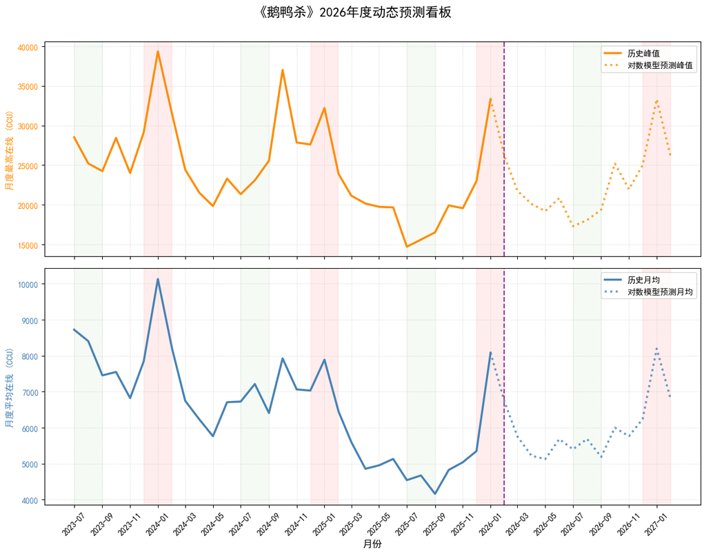

```python
plt.rcParams['font.sans-serif'] = ['SimHei']
plt.rcParams['axes.unicode_minus'] = False

fig, (ax1, ax2) = plt.subplots(nrows=2, ncols=1, figsize=(12, 10), sharex=True, gridspec_kw={'height_ratios': [1, 1.1]})
fig.suptitle('《鹅鸭杀》2026年度动态预测看板', fontsize=16, fontweight='bold', y=0.96)

ax1.plot(plot_df.index, plot_df['Peak Players'], color='darkorange', linewidth=2.5, label='历史峰值')
ax1.plot(df_predict_line.index, df_predict_line['Peak Players'], color='darkorange', linestyle=':', linewidth=2.5, alpha=0.8, label='对数模型预测峰值')
ax1.set_ylabel('月度最高在线 (CCU)', fontsize=11, fontweight='bold', color='darkorange')
ax1.tick_params(axis='y', labelcolor='darkorange')
ax1.grid(True, linestyle=':', alpha=0.5)
ax1.legend(loc='upper right')

ax2.plot(plot_df.index, plot_df['Avg. Players'], color='steelblue', linewidth=2.5, label='历史月均')
ax2.plot(df_predict_line.index, df_predict_line['Avg. Players'], color='steelblue', linestyle=':', linewidth=2.5, alpha=0.8, label='对数模型预测月均')
ax2.set_ylabel('月度平均在线 (CCU)', fontsize=11, fontweight='bold', color='steelblue')
ax2.tick_params(axis='y', labelcolor='steelblue')
ax2.grid(True, linestyle=':', alpha=0.5)
ax2.set_xlabel('月份', fontsize=12)
ax2.legend(loc='upper right')

split_date = pd.to_datetime('2026-01-31')
for ax in [ax1, ax2]:
    ax.axvline(split_date, color='purple', linestyle='--', linewidth=1.5, alpha=0.8)
    for year in [2023, 2024, 2025, 2026, 2027]:
        if 2024 <= year <= 2027:
            winter_start = pd.to_datetime(f'{year-1}-12-01')
            winter_end = pd.to_datetime(f'{year}-01-31')
            ax.axvspan(winter_start, winter_end, color='red', alpha=0.07)
        if year <= 2026:
            summer_start = pd.to_datetime(f'{year}-07-01')
            summer_end = pd.to_datetime(f'{year}-08-31')
            ax.axvspan(summer_start, summer_end, color='green', alpha=0.04)

all_dates = pd.date_range(start='2023-07-01', end='2027-02-28', freq='2MS')
plt.xticks(all_dates, [d.strftime('%Y-%m') for d in all_dates], rotation=45)
fig.tight_layout(rect=[0, 0.03, 1, 0.95])
plt.show()
```

# 4 2026年度《鹅鸭杀》人数走势预测分析

**① 整体趋势：缓降后筑底回稳**

**② 寒假窗口（2026、2027年1-2月）: 年初人数高峰**

**③ 暑期窗口（2026年7-9月）：小幅反弹，但回升空间有限**

# 5 运营建议

基于以上预测结论，提出如下差异化运营建议：

**旺季（1-2月、7-8月）：集中资源，主攻拉新与活跃**

寒假春节为全年最优流量窗口，应提前于12月底上线新版本内容或限时活动，借助春节社交聚合效应最大化老玩家召回与口碑提升；暑期酌情跟进轻量版本更新与社交赛事活动，承接季节性自然回流。

**淡季（3-6月、9-11月）：收缩预算，聚焦留存与口碑**

淡季削减泛流量宣发支出，转而以低成本签到福利、日常活动维稳现有用户，重点打磨游戏体验与口碑评分，为下一个旺季窗口蓄力。